# Data Exploration Project

Conner Deal

3/15/2022

## Introduction

The College Scorecard is a public-facing website that contains important information about colleges, including how much its graduates earn. Previously, this information was somewhat difficult to obtain, but with its release in September of 2015, we want to explore whether this information’s publication had meaningful impact on student searches for specific colleges. The purpose of this analysis seeks to find the causal effect of the Scorecard on searches using indexes from Google search data, and more specifically, evaluate whether the release of the scorecard shifted student interests to high-earning colleges vs. low-earning colleges that predominantly offer bachelor’s degrees.

## Libraries

Loading necessary libraries to conduct our analysis.

```r
library(car)
library(dplyr)
library(fixest)
library(jtools)
library(lubridate)
library(purrr)
library(tidyr)
library(tidyverse)
library(vtable)
```

## Cleaning the Data

Google trends data sets are separated because the files are too large, thus it breaks the system. However, we can download them individually and combine them into one working data set. This is then combined with data from the College Scorecard and with proper cleaning and filtering, we have a working data set to run some regressions and analysis.

##### Reading in the Google data and Scorecard Data

```r
trends_data_raw <- list.files(pattern = "trends_up_to") %>%
  map_dfr(read_csv)
SC_data <- read.csv("Most+Recent+Cohorts+(Scorecard+Elements).csv")
SC_dictionary <- read_csv("CollegeScorecardDataDictionary-09-08-2015.csv")
id_name_link <- read_csv("id_name_link.csv")
```

##### Removing duplicates from id_name_link file

```r
id_name_link <- id_name_link %>%
  group_by(schname) %>%
  mutate(N = n()) %>%
  filter(N == 1)

id_name_link <- id_name_link[1:3]
```

##### Isolating to show school index per month

```r
trends_data_raw <- trends_data_raw %>%
  mutate(month = str_sub(monthorweek, 1, 7)) %>%
  select(schname, keyword, index, month) %>%
  group_by(schname, keyword, month) %>%
  summarise(monthTotal = sum(index))
```

##### Creating binary variable for Scorecard implementation (before 2015 vs. after 2015)

```r
trends_data <- trends_data_raw %>%
  mutate(month = ym(month)) %>%
  mutate(after_2015 = month > ym('2015-09'))
```

##### Creating dummy varable for Seasonal control (Fall, Winter, Spring, Summer)

```r
trends_data <- trends_data %>%
  mutate(justmonth = month(month)) %>%
  mutate(Season = case_when(justmonth %in% c(12,1,2) ~ 'Winter',
                            justmonth %in% c(3,4,5) ~ 'Spring',
                            justmonth %in% c(6,7,8) ~ 'Summer',
                            justmonth %in% c(9,10,11) ~ 'Fall'))
```

##### Omitting NULL values and standardizing the index (visualization of standardized index included)

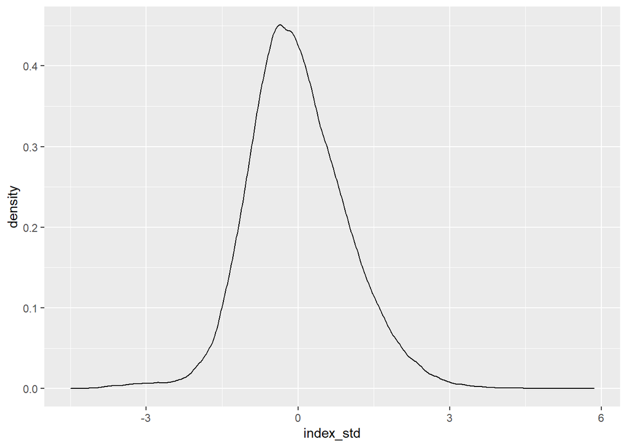

```r
trends_data <- trends_data %>% na.omit()

trends_data <- trends_data %>%
  group_by(schname, keyword) %>%
  mutate(index_std = (monthTotal - mean(monthTotal))/sd(monthTotal))

index_std_plot <- ggplot(trends_data, aes(x=index_std))+geom_density()
index_std_plot
```

###### College Scorecard for recent cohorts data is filtered.

Scorecard data set will include only primarily bachelor’s degree granting schools. Other NULL values or cells with unavailable data are also filtered out. Variables are characterized accordingly. The variables filtered and included from the Scorecard data are: unitid and opeid (for joining to Google data), STABBR (state), PREDDEG (primarily bachelor’s degree schools), LOCALE (size of local area surrounding school; i.e. city, suburban, rural), CONTROL (public vs. private vs. non-profit), HBCU (historically black colleges), MENONLY, WOMENONLY, PBI (predominantly black institute), HSI (hispanic serving institution), and MED_EARNINGS (median earnings of students post grad).

```r
SC_data <- rename(SC_data, unitid = UNITID,
                  opeid = OPEID,
                  MED_EARNINGS = "md_earn_wne_p10.REPORTED.EARNINGS")

SC_data <- SC_data %>% select(unitid, opeid, STABBR, PREDDEG,
                              LOCALE, CONTROL, HBCU, MENONLY,
                              WOMENONLY, PBI, HSI,
                              MED_EARNINGS)

SC_data <- SC_data %>%
  filter(PREDDEG == 3)%>%
  filter(MED_EARNINGS != "PrivacySuppressed" & MED_EARNINGS != "NULL")

SC_data$LOCALE <- as.numeric(SC_data$LOCALE)
SC_data$HBCU <- as.numeric(SC_data$HBCU)
SC_data$MENONLY <- as.numeric(SC_data$MENONLY)
SC_data$WOMENONLY <- as.numeric(SC_data$WOMENONLY)
SC_data$PBI <- as.numeric(SC_data$PBI)
SC_data$HSI <- as.numeric(SC_data$HSI)
SC_data$MED_EARNINGS <- as.numeric(SC_data$MED_EARNINGS)

vtable(SC_data)
```

SC_data

| Name | Class | Values |
| --- | --- | --- |
| unitid | integer | Num: 100654 to 475273 |
| opeid | integer | Num: 100200 to 82098821 |
| STABBR | character |  |
| PREDDEG | integer | Num: 3 to 3 |
| LOCALE | numeric | Num: 11 to 43 |
| CONTROL | integer | Num: 1 to 3 |
| HBCU | numeric | Num: 0 to 1 |
| MENONLY | numeric | Num: 0 to 1 |
| WOMENONLY | numeric | Num: 0 to 1 |
| PBI | numeric | Num: 0 to 1 |
| HSI | numeric | Num: 0 to 1 |
| MED_EARNINGS | numeric | Num: 11800 to 166200 |

##### Joining the Scorecard and Google data sets

```r
joined_id_trend <- left_join(id_name_link, trends_data, by = 'schname')
reg_data <- inner_join(SC_data, joined_id_trend, by = c('unitid', 'opeid'))
```

## Data Analysis

Before running regressions, we must first distinguish our cutoff for “High-Earning” vs. “Low-Earning” colleges. To do this, I refer to data from the Bureau of Labor Statistics that reports the median weekly earnings for full-time wage and salary workers age 25 and older with at least a bachelor’s degree to be 1,193 weekly in 2014, or $62,036 annually. I opted to use statistics from 2014 primarily because the scorecard was not yet implemented until September of 2015, meaning that the data reported in the scorecard is likely based off the previous fiscal year, thus using 2015 would be slightly inaccurate given that search index scores started in the tail end of 2015. A binary variable is then added to our data set that separates the high-earning (marked by a value of “1”) and low-earning schools (marked by a value of “0”).

```r
reg_data <- reg_data %>%
  mutate(HIGH_EARNING = MED_EARNINGS > 62036)
```

##### Regressions

The first model regresses our standardized index values on our post scorecard binary variable and our high earning binary variable, controlling for months.

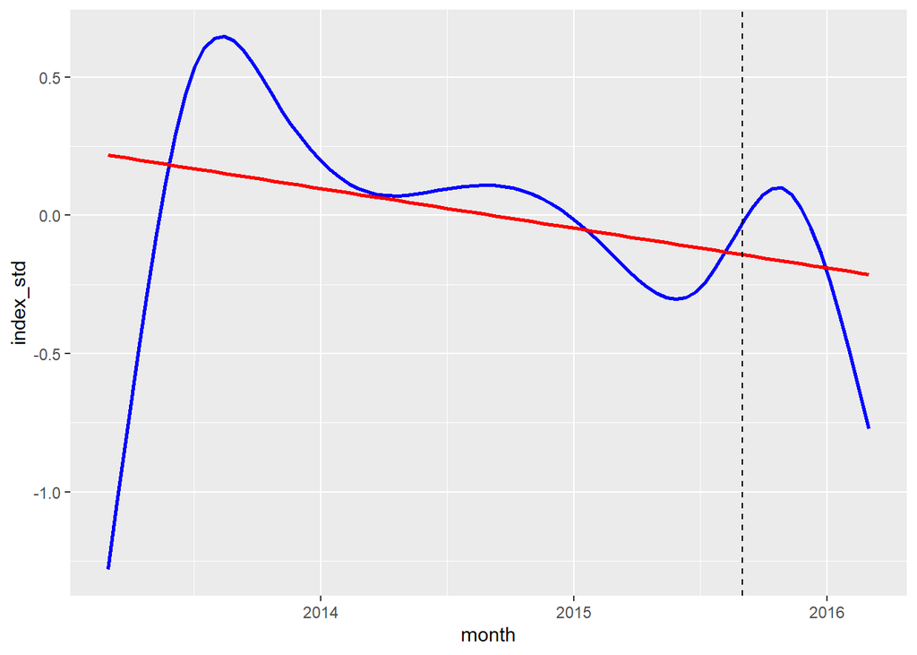

```r
reg1 <- lm(index_std ~ after_2015*HIGH_EARNING + month, data = reg_data)

reg1_graph <- ggplot(reg1, aes(x = month, y = index_std)) +
  geom_smooth(se = FALSE, color = 'blue') +
  geom_smooth(method = 'lm', se = FALSE, color = 'red') +
  geom_vline(xintercept = as.Date("2015-09-01"), linetype = "dashed")
reg1_graph
```

```r
export_summs(reg1)
```

|  | Model 1 |
| --- | --- |
| (Intercept) | 5.00 *** |
|  | (0.14) |
| after_2015TRUE | -0.12 *** |
|  | (0.01) |
| HIGH_EARNINGTRUE | -0.00 |
|  | (0.01) |
| month | -0.00 *** |
|  | (0.00) |
| after_2015TRUE:HIGH_EARNINGTRUE | 0.02 |
|  | (0.03) |
| N | 212567 |
| R2 | 0.02 |
| *** p < 0.001; ** p < 0.01; * p < 0.05. |  |

This first regression model indicates that the release of the scorecard resulted in 0.02 increase in the standardized searches for high-earning colleges compared to low-earning colleges.

The regression models two and three utilize season as a control, being different in the linear model versus fixed effects. Model four uses fixed effects on the month.

```r
reg2 <- lm(index_std ~ after_2015*HIGH_EARNING + Season, data = reg_data)

reg3 <- feols(index_std ~ after_2015*HIGH_EARNING | Season, data = reg_data)
```

```
## NOTE: 49 observations removed because of NA values (LHS: 49, RHS: 49, Fixed-effects: 49).
```

```r
reg4 <- feols(index_std ~ after_2015*HIGH_EARNING | month, data = reg_data)
```

```
## NOTE: 49 observations removed because of NA values (LHS: 49, RHS: 49, Fixed-effects: 49).
```

```
## The variable 'after_2015TRUE' has been removed because of collinearity (see $collin.var).
```

```r
# Regressions side by side
export_summs(reg1, reg2, reg3, reg4)
```

|  | Model 1 | Model 2 | Model 3 | Model 4 |
| --- | --- | --- | --- | --- |
| (Intercept) | 5.00 *** | 0.42 *** |  |  |
|  | (0.14) | (0.00) |  |  |
| after_2015TRUE | -0.12 *** | -0.32 *** | -0.32 |  |
|  | (0.01) | (0.01) | (0.13) |  |
| HIGH_EARNINGTRUE | -0.00 | -0.00 | -0.00 | -0.00 |
|  | (0.01) | (0.01) | (0.01) | (0.02) |
| month | -0.00 *** |  |  |  |
|  | (0.00) |  |  |  |
| after_2015TRUE:HIGH_EARNINGTRUE | 0.02 | 0.03 | 0.03 * | 0.03 |
|  | (0.03) | (0.03) | (0.01) | (0.04) |
| SeasonSpring |  | -0.52 *** |  |  |
|  |  | (0.01) |  |  |
| SeasonSummer |  | -0.42 *** |  |  |
|  |  | (0.01) |  |  |
| SeasonWinter |  | -0.53 *** |  |  |
|  |  | (0.01) |  |  |
| N | 212567 | 212567 | 212567 | 212567 |
| R2 | 0.02 | 0.06 | 0.06 | 0.44 |
| *** p < 0.001; ** p < 0.01; * p < 0.05. |  |  |  |  |

The second and third regression models indicate a 0.03 increase in the standardized searches for high-earning colleges compared to low-earning colleges, showing significance at the 95% level with our fixed effects model. The r squared value has also improved in models 2 and 3. Model 4 indicated the same effect from the scorecard, but produced a much better r squared value.

```r
# Additional regression controls (showed no impact)

reg5 <- lm(index_std ~ after_2015*HIGH_EARNING + HBCU, data = reg_data)

reg6 <- lm(index_std ~ after_2015*HIGH_EARNING + MENONLY, data = reg_data)

reg7 <- lm(index_std ~ after_2015*HIGH_EARNING + LOCALE, data = reg_data)

export_summs(reg5, reg6, reg7)
```

|  | Model 1 | Model 2 | Model 3 |
| --- | --- | --- | --- |
| (Intercept) | 0.05 *** | 0.05 *** | 0.05 *** |
|  | (0.00) | (0.00) | (0.01) |
| after_2015TRUE | -0.29 *** | -0.29 *** | -0.29 *** |
|  | (0.01) | (0.01) | (0.01) |
| HIGH_EARNINGTRUE | -0.00 | -0.00 | -0.00 |
|  | (0.01) | (0.01) | (0.01) |
| HBCU | -0.00 |  |  |
|  | (0.01) |  |  |
| after_2015TRUE:HIGH_EARNINGTRUE | 0.02 | 0.02 | 0.02 |
|  | (0.03) | (0.03) | (0.03) |
| MENONLY |  | 0.00 |  |
|  |  | (0.05) |  |
| LOCALE |  |  | 0.00 |
|  |  |  | (0.00) |
| N | 212567 | 212567 | 212567 |
| R2 | 0.01 | 0.01 | 0.01 |
| *** p < 0.001; ** p < 0.01; * p < 0.05. |  |  |  |

```r
# Season seems to be the only variable that we should control for to capture the effect.
```

The additional controls added in models 5, 6, and 7, have no strong influence on the model and do not improve it.

##### Linear hypothesis test

```r
linearHypothesis(reg1, 'after_2015TRUE + after_2015TRUE:HIGH_EARNINGTRUE = 0')
```

```
## Linear hypothesis test
##
## Hypothesis:
## after_2015TRUE  + after_2015TRUE:HIGH_EARNINGTRUE = 0
##
## Model 1: restricted model
## Model 2: index_std ~ after_2015 * HIGH_EARNING + month
##
##   Res.Df    RSS Df Sum of Sq      F    Pr(>F)
## 1 212563 203122
## 2 212562 203108  1    14.223 14.886 0.0001143 ***
## ---
## Signif. codes:  0 '***' 0.001 '**' 0.01 '*' 0.05 '.' 0.1 ' ' 1
```

Our p-value is low enough (<0.05) for us to reject the null hypothesis that the effect of the scorecard on high earning is 0. This indicates that there is in fact an effect, but our model is insufficient in truly capturing that effect.

##### Visualizations

```r
# Consolidation of standardized index scores to be one record per month
reg_data_monthly <- reg_data %>%
  group_by(month, HIGH_EARNING) %>%
  summarize(index_std = mean(index_std, na.rm = TRUE))
```

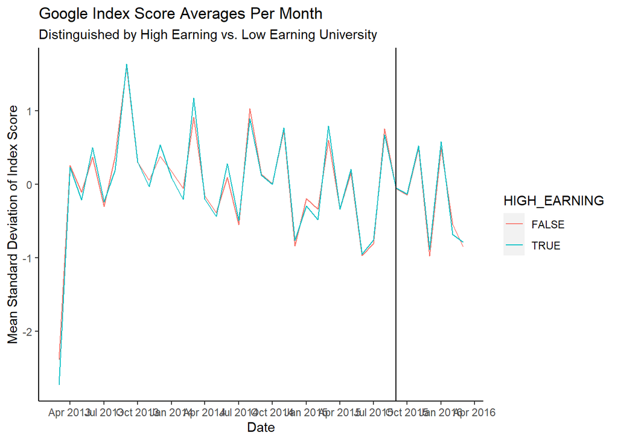

```r
ggplot() +
  geom_line(data = reg_data_monthly, aes(x = month, y = index_std, color = HIGH_EARNING)) +
  scale_x_date(breaks = scales :: breaks_pretty(13)) +
  geom_vline(xintercept = as.Date("2015-09-01")) +
  theme(panel.grid.major = element_blank(), panel.grid.minor = element_blank(),
        panel.background = element_blank(), axis.line = element_line(colour = "black")) +
  labs(title = "Google Index Score Averages Per Month",
       subtitle = "Distinguished by High Earning vs. Low Earning University",
       x = "Date", y = "Mean Standard Deviation of Index Score")
```

## Conclusion

Our regression model 3 showed some significance at the 95% level, indicating a 0.03 increase in the standardized searches for high-earning colleges compared to low-earning colleges. Additionally, our linear hypothesis test verifies that the effect is not 0. The graph above visualizes the slight difference in index score for high earning colleges versus low earning colleges after the implementation of the scorecard, but it seems to return to normal shortly after.